# Honduras1 Summary Report

26/03/2026

## Resumen de la encuesta

**Fechas de recopilación de datos:** : 2026-01-08 - 2026-01-19

| Forma | N |
| --- | --- |
| Formulario de indicadores | 37 |
| Forma femenina | 37 |
| Completó ambos formularios | 37 |
| Formulario de indicador completado únicamente | 0 |
| Formulario completado únicamente para mujeres | 0 |

## Muestra de datos demográficos

| **Característica** | **N = 37**<sup>1</sup> |
| --- | --- |
| loc1_name |  |
| Langue | 37 (100%) |
| Sexo del encuestado |  |
| F | 32 (86%) |
| M | 5 (14%) |
| Edad del encuestado | 51 (36, 57) |
| Formulario de mujeres Edad del encuestado | 51 (33, 58) |
| Educación (Jefe de hogar) |  |
| No hay escuela | 1 (2.7%) |
| Primario | 28 (76%) |
| Secundario | 7 (19%) |
| Postsecundaria | 0 (0%) |
| Educación de adultos, escuela de alfabetización o escuela parroquial | 0 (0%) |
| Sin respuesta | 1 (2.7%) |

<sup>1</sup> n (%); Median (Q1, Q3)

## Indicator Summary

[output not shown]

## PO.1 Productividad

**Definición objetiva** : Los hogares de pequeños agricultores han mejorado su capacidad para aumentar la productividad y la seguridad alimentaria mediante la transición de sus sistemas agrícolas a métodos agroecológicos.

### Producción de cultivos

| Cultivo | N (%) | Área media (Ha) | Rendimiento medio (kg) | Productividad media (kg/ha) |
| --- | --- | --- | --- | --- |
| Maíz | 36 (97.3%) | 1.01 | 5,808 | 8,650 |
| Frjoles colarados | 10 (27.0%) | 0.88 | 1,049 | 1,699 |
| yuca | 8 (21.6%) | 0.18 | 537 | 3,856 |
| Frijoles | 8 (21.6%) | 0.47 | 2,993 | 4,625 |
| Maicillo | 6 (16.2%) | 2.10 | 484 | 1,630 |
| Ayote | 4 (10.8%) | 0.04 | 60 | 1,371 |
| Guineos | 3 (8.1%) | 0.22 |  |  |
| Camote | 2 (5.4%) | 0.02 | 7 | 13,605 |
| Frijoles alacines | 2 (5.4%) | 0.71 | 499 | 708 |
| Nance | 2 (5.4%) | 0.04 | 27 | 622 |
| chile | 1 (2.7%) |  |  |  |
| Naranjos | 1 (2.7%) | 0.04 | 91 | 2,075 |
| Piña | 1 (2.7%) | 0.17 | 4,000 | 22,857 |
| Mango | 1 (2.7%) | 0.09 | 908 | 10,377 |
| cocos | 1 (2.7%) | 0.04 | 40 | 914 |
| Chile dulce | 1 (2.7%) |  |  |  |
| Chipilín | 1 (2.7%) | 0.09 |  |  |

Las entradas faltantes son resultado de utilizar unidades de medida sin confirmado conversiones a KG y/o HA

**Número de cultivos cultivados en una granja**

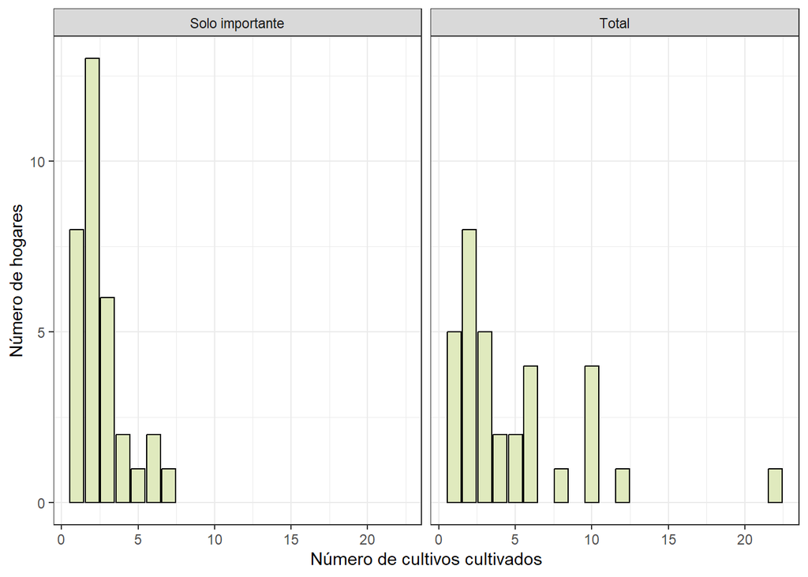

**Superficie de cultivos principales (Ha)**

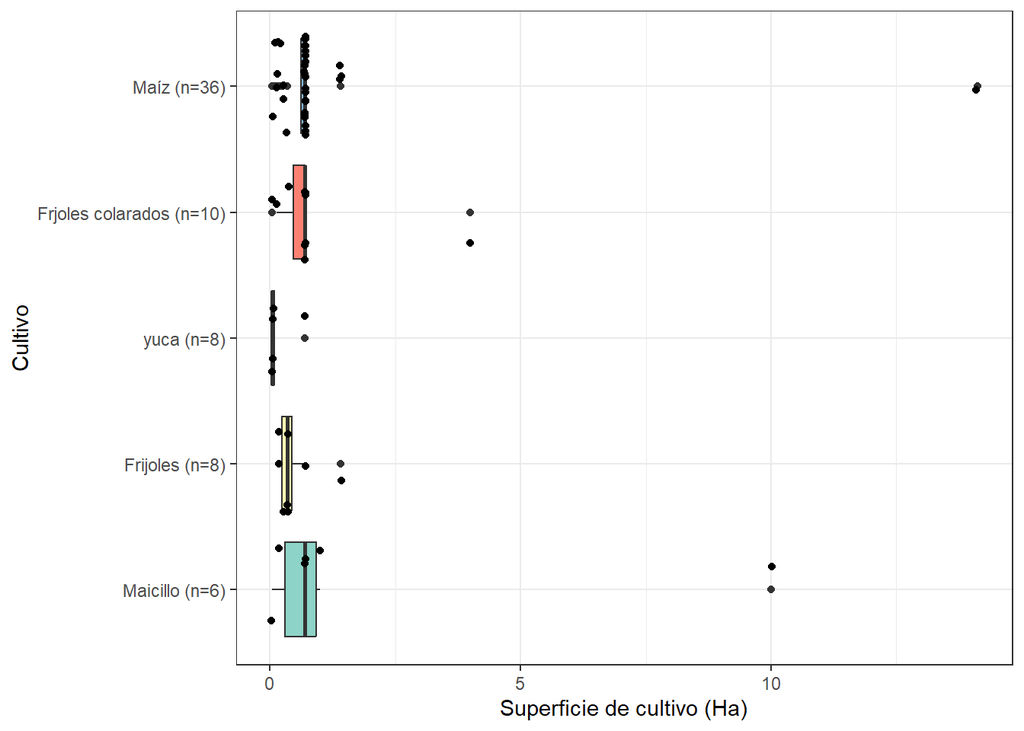

**Rendimiento de los cultivos (kg/ha)**

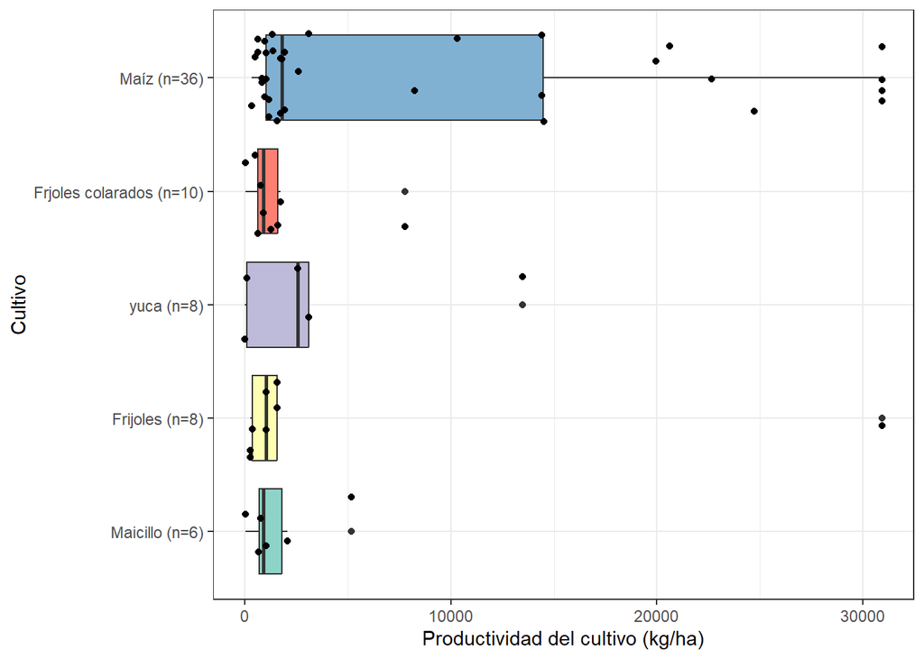

## PO.2 Empoderamiento de las mujeres

**Definición objetiva** : Las mujeres agricultoras han adquirido un mayor control sobre los recursos productivos y la toma de decisiones en sus hogares y comunidades.

**Proporción de hogares donde las mujeres tienen igual o mayor influencia o voz sobre…**

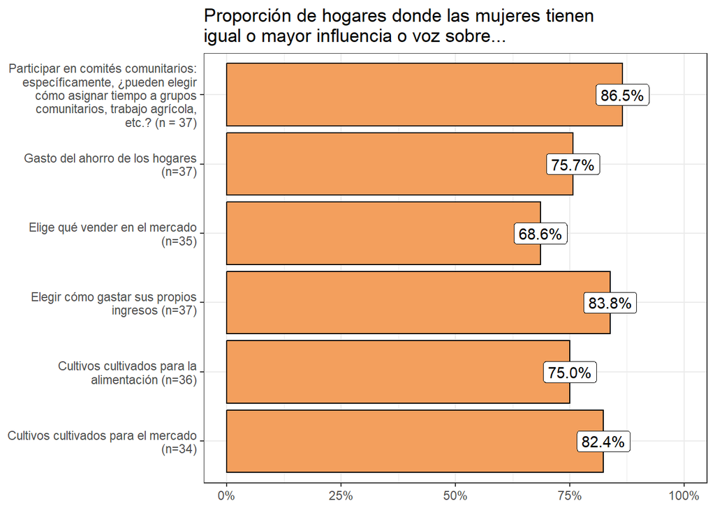

**A-WEAI - Acceso al capital productivo**

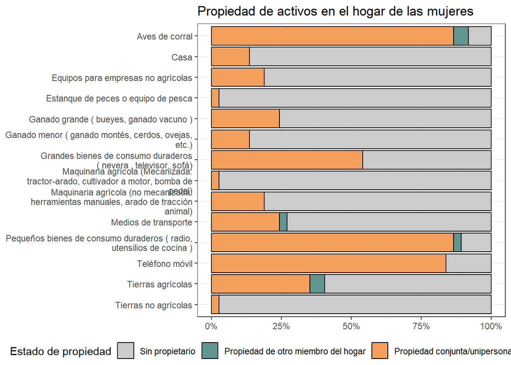

| Asset | Propiedad conjunta/unipersonal | Sin propietario | Propiedad de otro miembro del hogar |
| --- | --- | --- | --- |
| Tierras agrícolas | 35.1% | 59.5% | 5.4% |
| Ganado grande ( bueyes, ganado vacuno ) | 24.3% | 75.7% | 0.0% |
| Ganado menor ( ganado montés, cerdos, ovejas, etc.) | 13.5% | 86.5% | 0.0% |
| Aves de corral | 86.5% | 8.1% | 5.4% |
| Estanque de peces o equipo de pesca | 2.7% | 97.3% | 0.0% |
| Maquinaria agrícola (no mecanizada: herramientas manuales, arado de tracción animal) | 18.9% | 81.1% | 0.0% |
| Maquinaria agrícola (Mecanizada: tractor-arado, cultivador a motor, bomba de pedal) | 2.7% | 97.3% | 0.0% |
| Equipos para empresas no agrícolas | 18.9% | 81.1% | 0.0% |
| Casa | 13.5% | 86.5% | 0.0% |
| Grandes bienes de consumo duraderos ( nevera , televisor, sofá) | 54.1% | 45.9% | 0.0% |
| Pequeños bienes de consumo duraderos ( radio, utensilios de cocina ) | 86.5% | 10.8% | 2.7% |
| Teléfono móvil | 83.8% | 16.2% | 0.0% |
| Tierras no agrícolas | 2.7% | 97.3% | 0.0% |
| Medios de transporte | 24.3% | 73.0% | 2.7% |

## PO.3 Ingresos del hogar

**Definición objetiva** : Los hogares de pequeños agricultores han aumentado de manera sostenible sus ingresos y diversificado sus medios de vida con énfasis en los mercados locales.

### Mercados

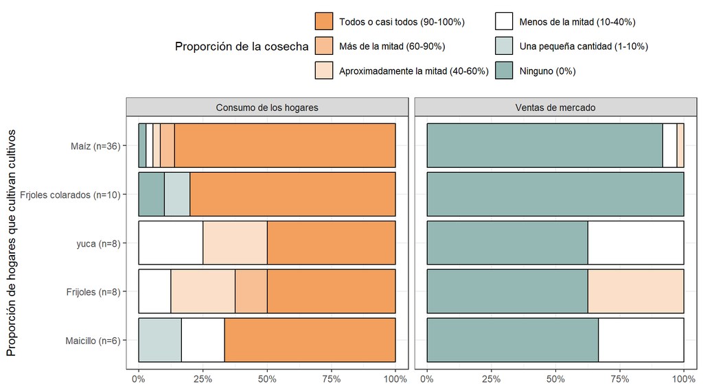

|  | **Frijoles** N = 8<sup>1</sup> | **Frjoles colarados** N = 10<sup>1</sup> | **Maicillo** N = 6<sup>1</sup> | **Maíz** N = 36<sup>1</sup> | **yuca** N = 8<sup>1</sup> |
| --- | --- | --- | --- | --- | --- |
| Consumo de los hogares |  |  |  |  |  |
| Todos o casi todos (90-100%) | 4 (50%) | 8 (80%) | 4 (67%) | 31 (86%) | 4 (50%) |
| Más de la mitad (60-90%) | 1 (13%) | 0 (0%) | 0 (0%) | 2 (5.6%) | 0 (0%) |
| Aproximadamente la mitad (40-60%) | 2 (25%) | 0 (0%) | 0 (0%) | 1 (2.8%) | 2 (25%) |
| Menos de la mitad (10-40%) | 1 (13%) | 0 (0%) | 1 (17%) | 1 (2.8%) | 2 (25%) |
| Una pequeña cantidad (1-10%) | 0 (0%) | 1 (10%) | 1 (17%) | 0 (0%) | 0 (0%) |
| Ninguno (0%) | 0 (0%) | 1 (10%) | 0 (0%) | 1 (2.8%) | 0 (0%) |
| Sin respuesta | 0 (0%) | 0 (0%) | 0 (0%) | 0 (0%) | 0 (0%) |
| Ventas de mercado |  |  |  |  |  |
| Todos o casi todos (90-100%) | 0 (0%) | 0 (0%) | 0 (0%) | 0 (0%) | 0 (0%) |
| Más de la mitad (60-90%) | 0 (0%) | 0 (0%) | 0 (0%) | 0 (0%) | 0 (0%) |
| Aproximadamente la mitad (40-60%) | 3 (38%) | 0 (0%) | 0 (0%) | 1 (2.8%) | 0 (0%) |
| Menos de la mitad (10-40%) | 0 (0%) | 0 (0%) | 2 (33%) | 2 (5.6%) | 3 (38%) |
| Una pequeña cantidad (1-10%) | 0 (0%) | 0 (0%) | 0 (0%) | 0 (0%) | 0 (0%) |
| Ninguno (0%) | 5 (63%) | 10 (100%) | 4 (67%) | 33 (92%) | 5 (63%) |
| Sin respuesta | 0 (0%) | 0 (0%) | 0 (0%) | 0 (0%) | 0 (0%) |

<sup>1</sup> n (%)

### Diversificación de ingresos

**Diversidad e importancia de las fuentes de ingresos**

| **Characteristic** | **N = 37**<sup>1</sup> |
| --- | --- |
| Fuente de ingresos |  |
| Crop farming + Off-farm sources | 15 (41%) |
| Crop farming only | 18 (49%) |
| Income sources unreported | 2 (5.4%) |
| Off-farm sources only | 2 (5.4%) |

<sup>1</sup> n (%)

| Fuente de ingresos | Hogares (n) | % |
| --- | --- | --- |
| Trabajo en otras granjas | 2 | 5.4% |
| Trabajo, no en una granja | 2 | 5.4% |
| Tener mi propio negocio | 4 | 10.8% |
| Remesas (enviar dinero) | 10 | 27.0% |
| Otro | 1 | 2.7% |

### Capacidad de ahorrar y pagar deudas

Hogares que informan de su situación financiera como “Podemos comprar todo lo que queremos y aún hay dinero para posibles ahorros”: 64.9%

¿Su hogar tiene algún crédito, deudas o préstamos, o tuvo alguno en los últimos 12 meses? 32.4%

¿Alguna vez le resultó difícil pagar las deudas en los últimos 12 meses?: 66.7%

### Autopercepción de la situación financiera

|  | **N = 37**<sup>1</sup> |
| --- | --- |
| Autopercepción de la situación financiera |  |
| Podemos comprar todo lo que queramos y aún queda dinero para posibles ahorros. | 24 (65%) |
| Podemos comprar todo lo que queramos sin problemas específicos pero no somos capaces de ahorrar | 0 (0%) |
| Vivimos económicamente y por eso podemos permitirnos todo. | 10 (27%) |
| Vivimos muy económicamente para ahorrar dinero para compras / eventos importantes. | 3 (8.1%) |
| Podemos comprar sólo la comida y la ropa más baratas y alquilar el apartamento más barato y (si la familia está endeudada) para pagar el préstamo. | 0 (0%) |
| Sólo podemos comprar la comida más barata y no tenemos dinero para devolver el préstamo ni para pagar ropa nueva o el alquiler. | 0 (0%) |
| No podemos permitirnos ni siquiera la comida más barata. | 0 (0%) |

<sup>1</sup> n (%)

## PO.4 Seguridad alimentaria y diversidad dietética

**Definición objetiva** : Los hogares vulnerables han mejorado la diversidad dietética y el estado nutricional.

### Diversidad dietética en el hogar

% Hogares que alcanzaron el nivel mínimo de diversidad (al menos 5 grupos de alimentos): 100.0%

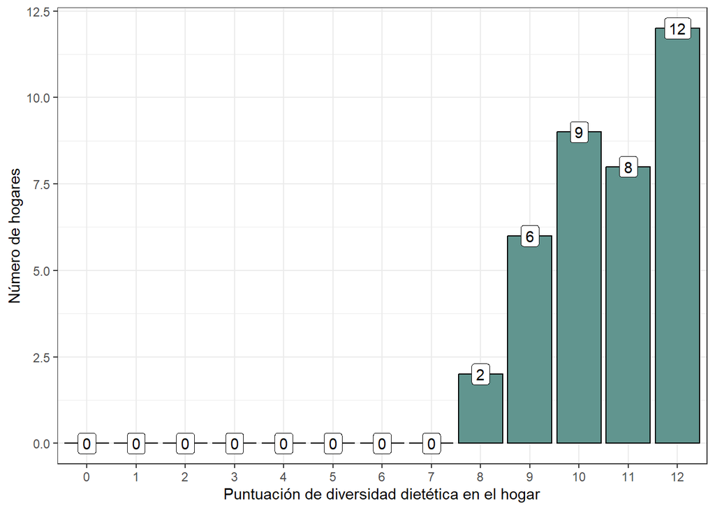

### FIES (Inseguridad alimentaria)

Porcentaje estimado de hogares con inseguridad alimentaria moderada o grave: 54.1%

| Categoría FIES | n | % |
| --- | --- | --- |
| Seguridad alimentaria<sup>1</sup> | 2 | 5.4% |
| Inseguridad alimentaria leve<sup>2</sup> | 15 | 40.5% |
| Inseguridad alimentaria moderada<sup>3</sup> | 18 | 48.6% |
| Inseguridad alimentaria grave<sup>4</sup> | 2 | 5.4% |

<sup>1</sup> Todas las preguntas de FIES = 'No'  
<sup>2</sup> FIES P5-P8 = 'No'  
<sup>3</sup> FIES P5, P6 o P7 = 'Sí'  
<sup>4</sup> FIES P8 = 'Sí'

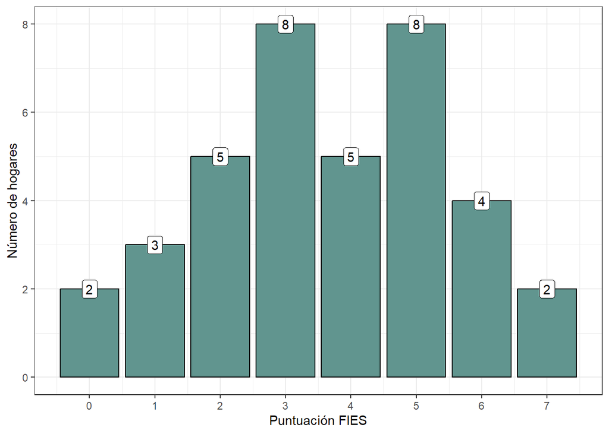

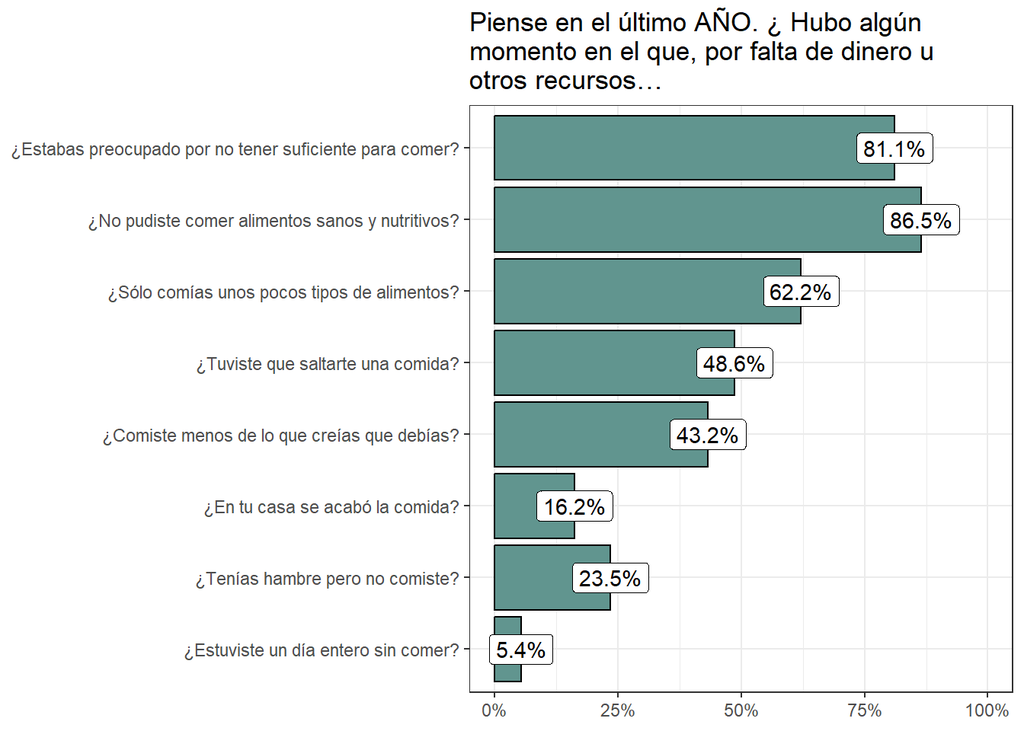